# PA1_template.html

JC

August 3, 2017

Reproducible Research Project 1: The variables included in this dataset are: steps: Number of steps taking in a 5-minute interval (missing values are coded as NA) date: The date on which the measurement was taken in YYYY-MM-DD format interval: Identifier for the 5-minute interval in which measurement was taken The dataset is stored in a comma-separated-value (CSV) file and there are a total of 17,568 observations in this dataset.

Commit containing full submission Code for reading in the dataset and/or processing the data — What is mean total number of steps taken per day?

For this part of the assignment, you can ignore the missing values in the dataset.

```
Calculate the total number of steps taken per day
If you do not understand the difference between a histogram and a barplot, research the difference between them. Make a histogram of the total number of steps taken each day
Calculate and report the mean and median of the total number of steps taken per day
```

Read in the activity data and change the date field from ‘Factor’ to ‘Date’

```r
library(plyr)
library(tidyr)
library(ggplot2)


activity <- read.csv("activity.csv"  )
class(activity$date)
```

```
## [1] "factor"
```

```r
activity$date <- as.Date(activity$date)
class(activity$date)
```

```
## [1] "Date"
```

```r
head(activity)
```

```
##   steps       date interval
## 1    NA 2012-10-01        0
## 2    NA 2012-10-01        5
## 3    NA 2012-10-01       10
## 4    NA 2012-10-01       15
## 5    NA 2012-10-01       20
## 6    NA 2012-10-01       25
```

Add in a primary key (row number) and a dummy variable to show if the Steps count is missing.

```r
activity <- mutate(activity , id= rownames(activity  ))
activity$id <- as.numeric(activity$id )
activity$steps_na <- is.na(activity$steps)
head(activity)
```

```
##   steps       date interval id steps_na
## 1    NA 2012-10-01        0  1     TRUE
## 2    NA 2012-10-01        5  2     TRUE
## 3    NA 2012-10-01       10  3     TRUE
## 4    NA 2012-10-01       15  4     TRUE
## 5    NA 2012-10-01       20  5     TRUE
## 6    NA 2012-10-01       25  6     TRUE
```

```
Calculate the total number of steps taken per day
If you do not understand the difference between a histogram and a barplot, research the difference between them. Make a histogram of the total number of steps taken each day
Calculate and report the mean and median of the total number of steps taken per day
```

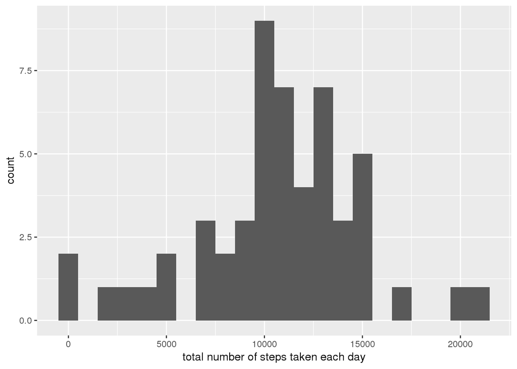

```r
activity_no_na <-subset(activity, steps_na==FALSE, select=c("steps","date", "interval", "id", "steps_na"))


total_steps_per_day <- ddply(activity_no_na, "date", function(x) {sum.count <- sum(x$steps)})
qplot( total_steps_per_day$V1 , binwidth=1000, xlab="total number of steps taken each day")
```

```r
mean(total_steps_per_day$V1)
```

```
## [1] 10766.19
```

```r
median(total_steps_per_day$V1)
```

```
## [1] 10765
```

What is the average daily activity pattern?

```
Make a time series plot (i.e. type = "l") of the 5-minute interval (x-axis) and the average number of steps taken, averaged across all days (y-axis)
```

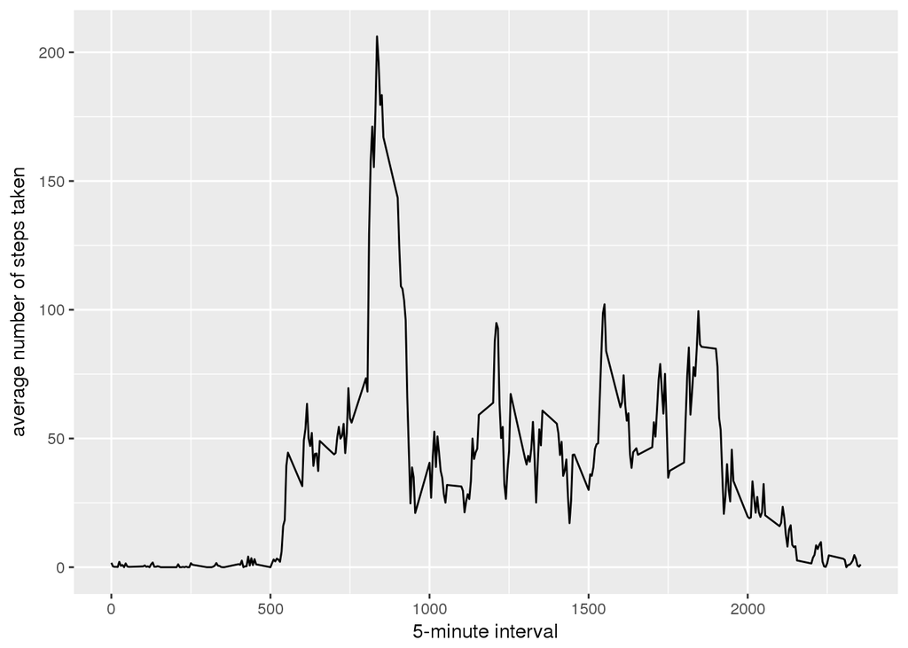

```
Which 5-minute interval, on average across all the days in the dataset, contains the maximum number of steps?
```

```r
interval_mean <-subset(activity, steps_na==FALSE, select=c("steps","date", "interval", "id", "steps_na"))
interval_mean <- ddply(interval_mean , "interval", function(x) {mean.count <- mean(x$steps)})
interval_mean$steps <- interval_mean$V1
ggplot(data=interval_mean , aes(x=interval, y=steps)) +
    geom_line() +
    xlab("5-minute interval") +
    ylab("average number of steps taken")
```

```r
interval_mean <-interval_mean  %>% arrange(desc(interval_mean$steps))
head(interval_mean)
```

```
##   interval       V1    steps
## 1      835 206.1698 206.1698
## 2      840 195.9245 195.9245
## 3      850 183.3962 183.3962
## 4      845 179.5660 179.5660
## 5      830 177.3019 177.3019
## 6      820 171.1509 171.1509
```

The interval with the highest step value is interval 835

Imputing missing values

Note that there are a number of days/intervals where there are missing values (coded as NA). The presence of missing days may introduce bias into some calculations or summaries of the data.

```
Calculate and report the total number of missing values in the dataset (i.e. the total number of rows with NAs)
Devise a strategy for filling in all of the missing values in the dataset. The strategy does not need to be sophisticated. For example, you could use the mean/median for that day, or the mean for that 5-minute interval, etc.
Create a new dataset that is equal to the original dataset but with the missing data filled in.
Make a histogram of the total number of steps taken each day and Calculate and report the mean and median total number of steps taken per day. Do these values differ from the estimates from the first part of the assignment? What is the impact of imputing missing data on the estimates of the total daily number of steps?
```

Code to take the interval mean for cases that are not missing steps. Repeat of some of the steps seen in the previous question.

```r
interval_mean <-subset(activity, steps_na==FALSE, select=c("steps","date", "interval", "id", "steps_na"))
interval_mean <- ddply(interval_mean , "interval", function(x) {mean.count <- mean(x$steps)})
interval_mean$steps_interval_mean <- interval_mean$V1
interval_mean <- subset(interval_mean, select = c( "interval", "steps_interval_mean"))
head(interval_mean)
```

```
##   interval steps_interval_mean
## 1        0           1.7169811
## 2        5           0.3396226
## 3       10           0.1320755
## 4       15           0.1509434
## 5       20           0.0754717
## 6       25           2.0943396
```

Code to indentify number of missing observations

```r
total_observations <- nrow(activity)
missing_observations <- sum(activity$steps_na)
print(total_observations )
```

```
## [1] 17568
```

```r
print(missing_observations)
```

```
## [1] 2304
```

Code to take the interval mean in steps and join back into the activity data and resort by primary key/id

```r
activity <- join(interval_mean, activity, by=c("interval"))

activity <- mutate(activity, modified_steps=ifelse(steps_na==TRUE,steps_interval_mean,steps))

head(activity %>% arrange(id))
```

```
##   interval steps_interval_mean steps       date id steps_na modified_steps
## 1        0           1.7169811    NA 2012-10-01  1     TRUE      1.7169811
## 2        5           0.3396226    NA 2012-10-01  2     TRUE      0.3396226
## 3       10           0.1320755    NA 2012-10-01  3     TRUE      0.1320755
## 4       15           0.1509434    NA 2012-10-01  4     TRUE      0.1509434
## 5       20           0.0754717    NA 2012-10-01  5     TRUE      0.0754717
## 6       25           2.0943396    NA 2012-10-01  6     TRUE      2.0943396
```

[output not shown]

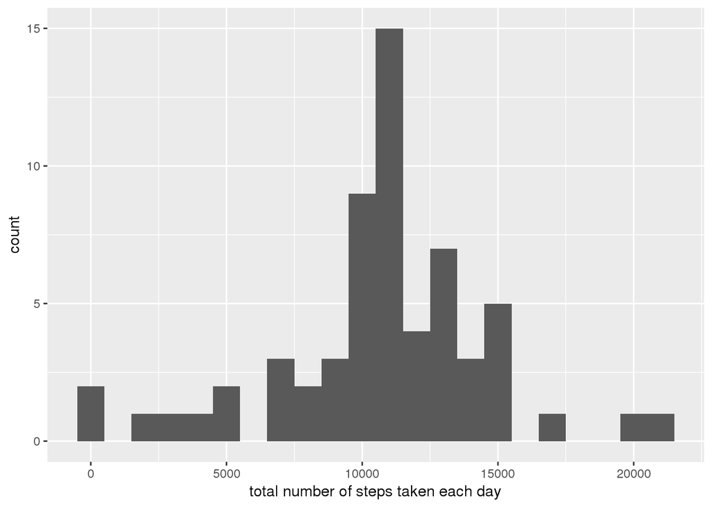

```r
steps_per_day <- ddply(activity, "date", function(x) {sum.count <- sum(x$modified_steps)})
qplot( steps_per_day$V1 , binwidth=1000, xlab="total number of steps taken each day")
```

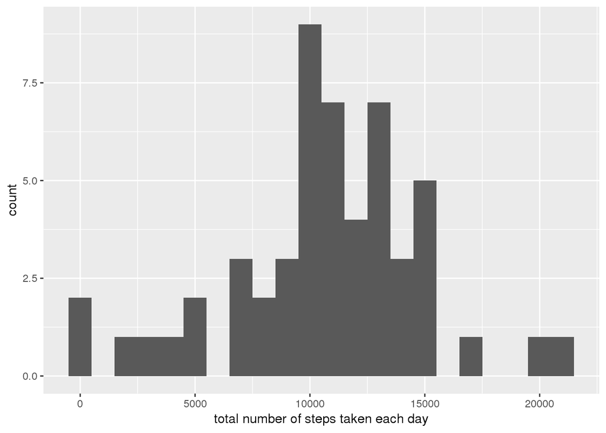

```r
print(qplot( total_steps_per_day$V1 , binwidth=1000, xlab="total number of steps taken each day"))
```

Calculate and report the mean and median total number of steps taken per day.

```r
mean(steps_per_day$V1)
```

```
## [1] 10766.19
```

```r
median(steps_per_day$V1)
```

```
## [1] 10766.19
```

Are there differences in activity patterns between weekdays and weekends?

For this part the weekdays() function may be of some help here. Use the dataset with the filled-in missing values for this part.

```
Create a new factor variable in the dataset with two levels – “weekday” and “weekend” indicating whether a given date is a weekday or weekend day.
```

```r
activity$weekday <- weekdays(activity$date)
activity <- mutate(activity, week_part=ifelse(weekday =="Saturday","WEEKEND",ifelse(weekday =="Sunday","WEEKEND","WEEKDAY")))

print(head(activity ))
```

```
##   interval steps_interval_mean steps       date   id steps_na
## 1        0            1.716981    NA 2012-10-01    1     TRUE
## 2        0            1.716981     0 2012-10-02  289    FALSE
## 3        0            1.716981     0 2012-10-03  577    FALSE
## 4        0            1.716981    47 2012-10-04  865    FALSE
## 5        0            1.716981     0 2012-10-05 1153    FALSE
## 6        0            1.716981     0 2012-10-06 1441    FALSE
##   modified_steps   weekday week_part
## 1       1.716981    Monday   WEEKDAY
## 2       0.000000   Tuesday   WEEKDAY
## 3       0.000000 Wednesday   WEEKDAY
## 4      47.000000  Thursday   WEEKDAY
## 5       0.000000    Friday   WEEKDAY
## 6       0.000000  Saturday   WEEKEND
```

[output not shown]

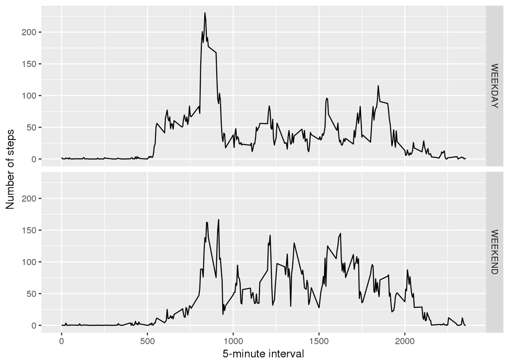

```r
week_mean <- ddply(activity ,c("interval" , "week_part"), function(x) {mean.count <- mean(x$modified_steps)})
week_mean$mean_steps <- week_mean$V1
week_mean <- subset(week_mean, select = c("interval", "week_part", "mean_steps"))


ggplot(week_mean, aes(interval, mean_steps)) + geom_line() + facet_grid(week_part ~ .) +    xlab("5-minute interval") + ylab("Number of steps")
```